# Analysis exercise, week 2

## About the data

This week I analyzed data about student’s learning strategies and their exam points on one introductory statistics course (more about data from [here](http://www.helsinki.fi/~kvehkala/JYTmooc/JYTOPKYS3-meta.txt)). First I read the dataset that I had previously cleaned as instructed.

```r
lrn14 <- read.table("./data/learning2014.txt", sep=" ", header=TRUE)
```

The new dataset I had created by choosing some variables from the original data and removing observationpoints where the exam points were 0, has 7 variables and 166 observations:

```r
dim(lrn14)
```

```
## [1] 166   7
```

These variables describe the gender, age, attitude, exam points and deep learning, surface learning and strategic learning approaches of the students. Gender has two values, male and female, age and points are integers and the rest of the variables have numerical values describing the average answer a student has given in the questions concerning the attitude and different learning approaches.

```r
str(lrn14)
```

```
## 'data.frame':    166 obs. of  7 variables:
##  $ gender  : Factor w/ 2 levels "F","M": 1 2 1 2 2 1 2 1 2 1 ...
##  $ age     : int  53 55 49 53 49 38 50 37 37 42 ...
##  $ attitude: num  3.7 3.1 2.5 3.5 3.7 3.8 3.5 2.9 3.8 2.1 ...
##  $ deep    : num  3.58 2.92 3.5 3.5 3.67 ...
##  $ stra    : num  3.38 2.75 3.62 3.12 3.62 ...
##  $ surf    : num  2.58 3.17 2.25 2.25 2.83 ...
##  $ points  : int  25 12 24 10 22 21 21 31 24 26 ...
```

## Exploring the data

There are lots of different tools to explore the data, and I start with printing a summary of the data:

```r
summary(lrn14)
```

```
##  gender       age           attitude          deep            stra
##  F:110   Min.   :17.00   Min.   :1.400   Min.   :1.583   Min.   :1.250
##  M: 56   1st Qu.:21.00   1st Qu.:2.600   1st Qu.:3.333   1st Qu.:2.625
##          Median :22.00   Median :3.200   Median :3.667   Median :3.188
##          Mean   :25.51   Mean   :3.143   Mean   :3.680   Mean   :3.121
##          3rd Qu.:27.00   3rd Qu.:3.700   3rd Qu.:4.083   3rd Qu.:3.625
##          Max.   :55.00   Max.   :5.000   Max.   :4.917   Max.   :5.000
##       surf           points
##  Min.   :1.583   Min.   : 7.00
##  1st Qu.:2.417   1st Qu.:19.00
##  Median :2.833   Median :23.00
##  Mean   :2.787   Mean   :22.72
##  3rd Qu.:3.167   3rd Qu.:27.75
##  Max.   :4.333   Max.   :33.00
```

From the summary we can for example see that the youngest respondant is only 17, where as the oldest is 55. The values of attitude variable range from 1.4 to full 5, so someone seems to be not at all interested in statistics, where at least one person seems to be highly motivated. The different learning approaches have similar minimal and maximal values.

To explore the data visually I will be using the R library GGally and it’s pair plotting function here. With GGally I plotted a concise picture about the correlations and distributions of the variables, separately for females and males. Females are coloured red and males blue in the picture.

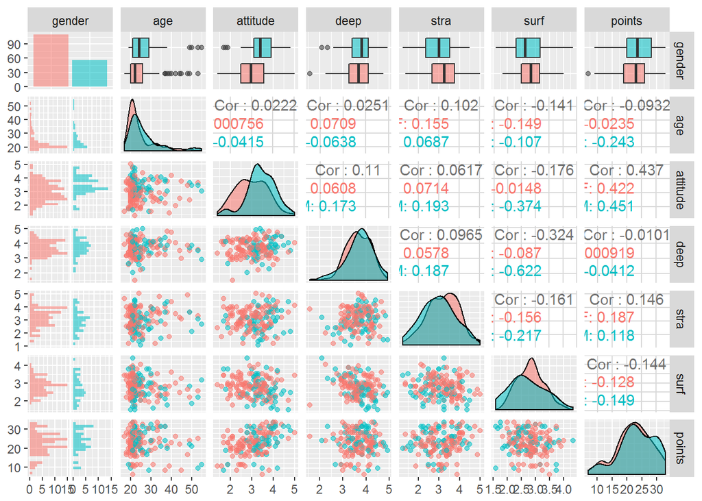

```r
library(GGally)
library(ggplot2)
p <- ggpairs(lrn14, mapping = aes(col = gender, alpha = 0.3), lower = list(combo = wrap("facethist", bins = 20)))
p
```